# Econometria II

Mestrado em Administração  
Aula 8

Prof. Washington Santos da Silva

IFMG - Campus Formiga

22 de abril de 2026

## Na aula anterior

**Tópicos**

- Passeio Aleatório em Economia/Econometria
- Testes de Raiz Unitária e Estacionariedade
- Exemplo Empírico
- Testes de Raiz Unitária com Quebra Estrutural
- Exercício

## Nesta aula

**Tópicos**

- Regressão com variáveis não estacionárias:
  - Tendências estocásticas e regressão espúria
  - Cointegração
  - Modelo de Correção de Erros (ECM)
  - Testes de cointegração
  - Sem cointegração: ARDL em primeiras diferenças

# Cointegração

## Tendências estocásticas

**Problema central**

- Tendências **determinísticas** podem ser tratadas facilmente — basta incluí-las no modelo ou **remover a tendência** das variáveis.
- Tendências **estocásticas** são a principal fonte de não-estacionariedade e introduzem problemas especiais.
- Com variáveis não-estacionárias, os estimadores de MQO **perdem** suas propriedades usuais — intervalos de confiança e testes $t$ **não são confiáveis**.
- Em séries I(1), cada choque $\varepsilon_t$ tem efeito **permanente**; em séries estacionárias, o efeito de um choque é **transitório**.
- Risco central — a **regressão espúria**: dois passeios aleatórios independentes podem exibir forte relação linear aparente que não existe.

**Pergunta:** *quando uma regressão em nível entre séries não-estacionárias faz sentido?*

## Tendência determinística

**Descrição**

Considere duas séries simuladas por:

$$x_t = 10 + 0.05\, t + u_t, \qquad y_t = 5 + 0.08\, t + v_t,$$

com $u_t$ e $v_t$ estacionários e independentes entre si.

- Aqui o crescimento vem de uma **tendência determinística** comum no tempo, não de choques permanentes acumulados.
- Se omitirmos $t$, `x_t` pode parecer relevante apenas porque ambas as séries crescem com o calendário.
- O tratamento correto é **incluir tendência** na regressão ou **remover a tendência** das séries.
- Portanto, esse caso pede um ajuste de especificação, não o tipo de problema que estudaremos a seguir.

## Séries com tendência determinística

```r
# fixa a semente para reprodutibilidade
set.seed(123)

# tamanho das séries simuladas
n_det <- 200

# tendência determinística
tempo_det <- 1:n_det

# simula os choques
u_det <- as.numeric(arima.sim(list(ar = 0.6), n = n_det, sd = 1))
v_det <- as.numeric(arima.sim(list(ar = 0.4), n = n_det, sd = 1))

# simula as séries com tendência determinística
x_det <- 10 + 0.05 * tempo_det + u_det
y_det <- 5 + 0.08 * tempo_det + v_det

# armazena as séries em uma base longa
dados_det <- tibble(
  tempo = tempo_det,
  x = x_det,
  y = y_det
) |>
  pivot_longer(
    cols = c(x, y),
    names_to = "serie",
    values_to = "valor"
  )

# gráfico das séries simuladas
ggplot(dados_det, aes(x = tempo, y = valor, color = serie)) +
  geom_line(linewidth = 0.8) +
  scale_color_manual(
    values = c("x" = "#1F6E8C", "y" = "#D97706"),
    labels = c("x_t", "y_t")
  ) +
  labs(x = "Tempo", y = "Valor", color = "Série") +
  theme_minimal(base_size = 16)
```

## Séries com tendência determinística

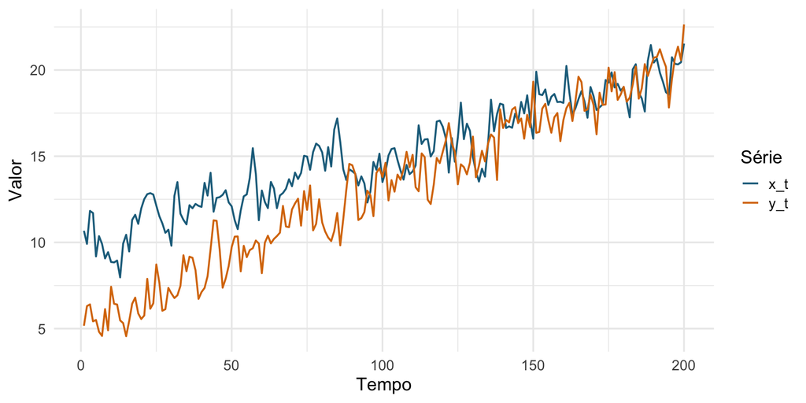

As duas séries crescem ao longo do tempo, mas esse co-movimento vem da tendência determinística comum. Aqui, o ajuste correto é controlar o tempo na regressão.

## Código: tendência determinística

```r
# comparamos a regressão sem tendência com a especificação correta
modelo_sem_tend <- lm(y_det ~ x_det)
modelo_com_tend <- lm(y_det ~ x_det + tempo_det)

# inspecionamos os dois resultados
summary(modelo_sem_tend)
summary(modelo_com_tend)
```

## Resultados: tendência determinística

Com tendência determinística, omitir o tempo faz x parecer relevante; ao incluir a tendência, essa falsa relevância desaparece.

| Modelo | Coef. x | p-valor x | Coef. tendência | p-valor tendência |
| --- | --- | --- | --- | --- |
| Sem tendência | 1.352 | <0.001 |  |  |
| Com tendência | 0.005 | 0.938 | 0.078 | <0.001 |

## Leitura: tendência determinística

**Interpretação**

- Sem controlar o tempo, `x_det` parece relevante porque absorve a tendência determinística comum às duas séries.
- Ao incluir `tempo_det`, essa falsa relevância desaparece: o coeficiente de `x_det` perde significância e a tendência passa a concentrar a explicação do crescimento conjunto.
- O ponto importante não é obter resíduos de **ruído branco**, mas sim remover a tendência comum e evitar atribuir a `x_det` um efeito espúrio.
- Como os choques foram simulados como AR(1), é natural que, mesmo após a especificação correta, reste dependência serial estacionária nos resíduos.

## O que o gráfico não prova?

**Transição**

- Crescimento conjunto no gráfico **não basta** para concluir que há **tendência estocástica**.
- Neste exemplo, o co-movimento vem de uma **tendência determinística comum**.
- Antes de avançar, precisamos distinguir **tendência determinística** de **tendência estocástica**.
- Só depois dessa distinção é que entra o problema central da aula: a **regressão espúria** com séries não-estacionárias.

## Passeios aleatórios independentes

**Hipótese da simulação**

Considere duas séries geradas por:

$$x_t = x_{t-1} + \varepsilon_{xt}, \qquad \varepsilon_{xt} \sim N(0, \sigma_x^2)$$

$$y_t = y_{t-1} + \varepsilon_{yt}, \qquad \varepsilon_{yt} \sim N(0, \sigma_y^2)$$

com choques independentes:

$$\operatorname{Cov}(\varepsilon_{xt}, \varepsilon_{yt}) = 0$$

- Cada série é um **passeio aleatório** e, portanto, **I(1)**.
- Como os choques são independentes, **não há relação estrutural** entre $x_t$ e $y_t$.
- Se a regressão em nível parecer forte, isso será um caso de **regressão espúria**.

## Regressão espúria

```r
# simulação: duas séries temporais que não têm relação entre si
library(tidyverse)

# fixa a semente para reprodutibilidade
set.seed(21)
# tamanho das séries simuladas
n <- 500
# inicializa os vetores
y <- numeric(n)
x <- numeric(n)

# dois passeios aleatórios independentes
for (t in 2:n) {
  y[t] <- y[t-1] + rnorm(1)
  x[t] <- x[t-1] + rnorm(1)
}

# armazena as séries em uma base longa
dados <- data.frame(t = 1:n, x = x, y = y) |>
  pivot_longer(cols = c(x, y), names_to = "serie", values_to = "valor")

# gráfico dos passeios aleatórios
ggplot(dados, aes(x = t, y = valor, color = serie)) +
  geom_line() +
  scale_color_manual(
    values = c("x" = "steelblue", "y" = "tomato"),
    labels = c(expression(x[t]), expression(y[t]))
  ) +
  labs(title = "Dois passeios aleatórios independentes",
       x = "Tempo (t)", y = "Valor", color = "Série") +
  theme_minimal()
```

## Regressão espúria

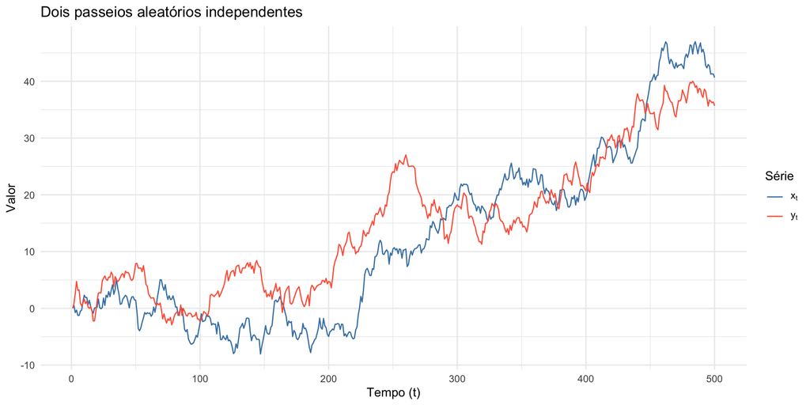

## Dispersão enganosa

```r
# gráfico de dispersão entre as séries
ggplot(data.frame(x, y), aes(x, y)) +
  geom_point() +
  geom_smooth(method = "lm", se = FALSE) +
  labs(x = expression(x[t]), y = expression(y[t])) +
  theme_minimal()
```

## Dispersão enganosa

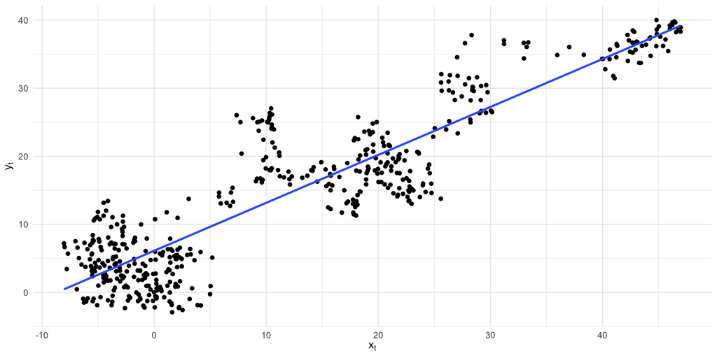

Apesar de serem independentes, o gráfico sugere uma relação linear. A aparente relação é **produto da não-estacionariedade**, não de vínculo econômico.

## Código: regressão espúria

```r
# estima a regressão em nível entre duas séries independentes
modelo_regressao <- lm(y ~ x)

# inspeciona o ajuste aparente da regressão
summary(modelo_regressao)

# testa autocorrelação serial dos resíduos
lmtest::bgtest(modelo_regressao, order = 1)
```

## Resultados: regressão espúria

Regressão espúria: coeficientes e diagnóstico

| Termo | Estimativa | Erro-padrao | Estatistica | p-valor |
| --- | --- | --- | --- | --- |
| Intercepto | 6.111 | 0.286 | 21.348 | <0.001 |
| x | 0.704 | 0.015 | 48.472 | <0.001 |
| R² | 0.825 |  |  |  |
| Breusch-Godfrey (1) |  |  | 472.110 | <0.001 |

## Sinais de regressão espúria

**Evidências**

- $R^2 \approx 0{,}83$ — **ajuste aparentemente muito bom**.
- Coeficiente $\hat{\beta}$ aparentemente **significativo**.
- Resíduos **fortemente autocorrelacionados**.
- Breusch–Godfrey (ordem 1): estatística $\approx 472{,}11$, $p\ll 0{,}01$ — **sinal claro de regressão espúria**.

## Lição da regressão espúria

**Mensagem**

- Uma regressão **em nível** entre séries I(1) pode parecer excelente e ser **completamente sem sentido**.
- A significância aparente decorre apenas do fato de que **ambas as séries têm tendência estocástica** — mesmo sem qualquer vínculo econômico entre elas.
- Precisamos de um **critério** para distinguir relação espúria de relação econômica genuína.
- Esse critério é a **cointegração**.

## O que é cointegração

**Definição intuitiva**

- Em geral, se $y_t$ e $x_t$ são I(1), qualquer combinação linear

$$e_t = y_t - \beta_1 - \beta_2\, x_t$$

também será I(1).

- **Exceção importante:** se $e_t \sim I(0)$, dizemos que $y_t$ e $x_t$ são **cointegradas**.
- Nesse caso, $y_t$ e $x_t$ compartilham **tendências estocásticas comuns** e nunca se afastam demasiadamente uma da outra ao longo do tempo.

## Intuição econômica

**Exemplo: juros**

- Taxas de juros de curto e longo prazo são altamente correlacionadas e tendem a ser **não-estacionárias**.
- Porém, a diferença entre elas — o **spread de prazo** — é muito menos persistente e **não** mostra evidências de não-estacionariedade.
- Logo, taxas de curto e longo prazo tendem a ser **cointegradas**.

**Mensagem:** séries individualmente não-estacionárias podem ter um **desvio estacionário**.

## Equilíbrio de longo prazo

**Aplicações**

- Preços à vista e futuros.
- Razão de preços relativos e taxa de câmbio.
- Preços de ações e dividendos.

**Interpretação:**

- Forças de mercado e condições de **não-arbitragem** devem garantir uma relação de **equilíbrio**.
- A **ausência** de cointegração implica que as séries podem se afastar indefinidamente no longo prazo.
- Cointegração é, portanto, uma noção de **equilíbrio econômico de longo prazo**.

## Definição de cointegração

**Ordem CI($d$, $b$)**

Seja $z_t$ um vetor $k \times 1$ de séries temporais. **Os componentes de** $z_t$ são cointegrados de ordem $(d,b)$ se:

1. Todos os componentes de $z_t$ são $I(d)$;
2. Existe $\alpha \neq 0$ tal que

$$\alpha^{\prime} z_t \sim I(d-b).$$

- Caso mais relevante em Finanças/Economia: $d=b=1$ — séries **I(1)** cuja combinação linear é **I(0)**.
- Pode haver até $r$ vetores de cointegração linearmente independentes ($r \leq k-1$); $r$ é o **posto de cointegração**.

## Por que diferenças não bastam

**Perda do longo prazo**

Considere $y_t$ e $x_t$, ambos I(1). Um modelo ingênuo:

$$\Delta y_t = \beta\, \Delta x_t + u_t$$

- No longo prazo, $y_t = y_{t-1} = y$ e $x_t = x_{t-1} = x$, então

$$\Delta y_t = 0, \qquad \Delta x_t = 0.$$

- O modelo **colapsa para nada** — não há solução de longo prazo.
- Modelos apenas em diferenças **descartam** a informação de equilíbrio contida nos níveis.

## Modelo de Correção de Erros (ECM)

**Equação básica**

$$\Delta y_t = a_1\, \Delta x_t + a_2\big(y_{t-1} - \gamma\, x_{t-1}\big) + u_t$$

- $\Delta x_t$ — dinâmica de **curto prazo**.
- $(y_{t-1} - \gamma\, x_{t-1})$ — **erro de equilíbrio defasado**, isto é, o desvio em relação ao equilíbrio de longo prazo no período anterior.

O modelo recebe esse nome porque, quando esse erro de equilíbrio defasado é diferente de zero, a dinâmica de $\Delta y_t$ responde de modo a **reduzir esse desvio** no período corrente.

Se $y_t$ e $x_t$ são cointegradas com coeficiente $\gamma$, então $(y_{t-1} - \gamma x_{t-1})$ é I(0) e pode-se usar **MQO** validamente.

**Teorema da Representação de Granger:** toda relação de cointegração admite uma representação ECM.

## Ajuste ao equilíbrio

**Mecanismo de ajuste**

- Se $y_{t-1}$ está **acima** do equilíbrio ($y_{t-1} > \gamma\, x_{t-1}$), a dinâmica futura tende a **puxá-lo para baixo**: $\Delta y_t < 0$.
- Se está **abaixo** ($y_{t-1} < \gamma\, x_{t-1}$), a dinâmica tende a **puxá-lo para cima**: $\Delta y_t > 0$.
- Para que essa correção ocorra, é necessário $a_2 < 0$; a **magnitude** $|a_2|$ mede a velocidade de retorno ao equilíbrio.
- Valores típicos em aplicações: $-1 < a_2 < 0$ — quanto mais próximo de $-1$, mais rápido o ajuste.

**Mensagem:** o ECM descreve como **desvios do equilíbrio econômico são corrigidos ao longo do tempo**.

## Ponte com a Aula 2

**Relembrando o ARDL**

- Na Aula 2, vimos os **modelos autorregressivos de defasagem distribuída** (*Autoregressive Distributed Lag*), abreviados como **ARDL**.
- Em um **ARDL($p,q$)**, a variável dependente responde a **defasagens próprias** e também a **defasagens das variáveis explicativas**.

$$y_t = \alpha + \phi_1 y_{t-1} + \cdots + \phi_p y_{t-p} + \beta_0 x_t + \beta_1 x_{t-1} + \cdots + \beta_q x_{t-q} + u_t$$

- Na Aula 2, o foco era a **dinâmica** e a **escolha de defasagens**.
- Na Aula 8, esse mesmo modelo reaparece em dois papéis: com **cointegração**, ele pode ser reescrito como **ECM**; sem cointegração, trabalhamos com o **ARDL em primeiras diferenças**.

## Do ARDL ao ECM

**ARDL inicial**

Um modelo autorregressivo de defasagem distribuída, **ARDL(1,1)**, com variáveis potencialmente não-estacionárias:

$$y_t = \delta + \theta_1\, y_{t-1} + \delta_0\, x_t + \delta_1\, x_{t-1} + v_t$$

- A derivação vale para **qualquer** ordem de defasagens.
- **Mensagem:** o ECM **não surge do nada** — um ARDL com variáveis cointegradas pode ser **reescrito** como ECM.

## Equilíbrio implícito

**Relação de longo prazo**

Fazendo $y_t = y_{t-1} = y$, $x_t = x_{t-1} = x$ e $v_t = 0$:

$$y(1 - \theta_1) = \delta + (\delta_0 + \delta_1)\, x$$

Reescrevendo:

$$y = \beta_1 + \beta_2\, x,
\qquad
\beta_1 = \frac{\delta}{1 - \theta_1}, \quad
\beta_2 = \frac{\delta_0 + \delta_1}{1 - \theta_1}.$$

Esta é a **relação de cointegração implícita** no ARDL — ligando ARDL ao conceito de longo prazo.

## Forma final do ECM

**Equação final**

Após bastante algebra, obtemos:

$$\boxed{\;\Delta y_t=-\alpha\,\big(y_{t-1}-\beta_1-\beta_2\,x_{t-1}\big)+\delta_0\,\Delta x_t+v_t\;}$$

com $\alpha = 1 - \theta_1$.

- Termo entre parênteses — **desvio do equilíbrio de longo prazo**.
- $-\alpha$ — **intensidade (velocidade) do ajuste**.
- Condição para ajuste estável: $\alpha > 0 \;\Leftrightarrow\; \theta_1 < 1$.

## Como ler o ECM

**Componentes do modelo**

- **Curto prazo:** $\delta_0\, \Delta x_t$ — resposta contemporânea às variações em $x$.
- **Longo prazo:** $y_{t-1} - \beta_1 - \beta_2\, x_{t-1}$ — desvio em relação ao equilíbrio.
- **Velocidade de ajuste:** $\alpha$ — com que rapidez o sistema retorna ao equilíbrio.

**Por que o ECM é popular:**

- Combina variáveis I(1) (em níveis) e I(0) (em diferenças) **na mesma equação** — desde que haja cointegração.
- Traduz a álgebra em linguagem econômica clara: **dinâmica + equilíbrio**.

## Por que “correção de erros”?

**Intuição do nome**

Na forma equivalente,

$$\Delta y_t = (\theta_1 - 1)\,\big(y_{t-1} - \beta_1 - \beta_2 x_{t-1}\big) + \delta_0\,\Delta x_t + v_t,$$

o termo $y_{t-1} - \beta_1 - \beta_2 x_{t-1}$ mede o desvio de $y_{t-1}$ em relação ao seu valor de longo prazo, $\beta_1 + \beta_2 x_{t-1}$. Em outras palavras, ele representa o “erro” herdado do período anterior.

O fator $(\theta_1 - 1)$ mostra como $\Delta y_t$ reage a esse erro. Como $\alpha = 1 - \theta_1$, temos $(\theta_1 - 1) = -\alpha$.

- Se $y_{t-1} > \beta_1 + \beta_2 x_{t-1}$, então o erro defasado é positivo. Para corrigi-lo, $y_t$ deve cair, de modo que $\Delta y_t < 0$.
- Se $y_{t-1} < \beta_1 + \beta_2 x_{t-1}$, então o erro defasado é negativo. Para corrigi-lo, $y_t$ deve subir, de modo que $\Delta y_t > 0$.

Se existe cointegração entre $y$ e $x$, os ajustamentos tendem a atuar na direção de correção do desvio. Assim, empiricamente esperamos:

$$1 - \theta_1 > 0.$$

Isso implica $\theta_1 < 1$.

## Popularidade do ECM

**Por que ele é tão popular?**

O **modelo de correção de erros** é muito popular porque permite combinar, na mesma equação, a **relação de longo prazo** entre as variáveis e os **ajustamentos de curto prazo** em direção ao equilíbrio. Ele também mostra que podemos trabalhar com variáveis $I(1)$ ($y_{t-1}$, $x_{t-1}$) e variáveis $I(0)$ ($\Delta y_t$, $\Delta x_t$), desde que $(y, x)$ sejam cointegradas, isto é, desde que o termo

$$y_{t-1} - \beta_1 - \beta_2 x_{t-1}$$

contenha resíduos estacionários. Nessa formulação, o próprio ECM também fornece uma base para **testar cointegração** entre $y$ e $x$.

## Estimação do ECM

**Duas estratégias**

Para estimar a equação do ECM, há **duas estratégias principais**:

- substituir o termo $y_{t-1} - \beta_1 - \beta_2 x_{t-1}$ por $\hat{e}_{t-1}$, obtido na regressão de longo prazo;
- estimar simultaneamente $\alpha$, $\beta_1$, $\beta_2$ e $\delta_0$ na equação

$$\Delta y_t=-\alpha\,\big(y_{t-1}-\beta_1-\beta_2 x_{t-1}\big)+\delta_0\,\Delta x_t+v_t.$$

Nessa segunda abordagem, podemos usar **mínimos quadrados não lineares** diretamente ou reparametrizar o modelo para estimá-lo por **MQO**:

$$\Delta y_t = \beta_1^* + \alpha^* y_{t-1} + \beta_2^* x_{t-1} + \delta_0\, \Delta x_t + v_t.$$

Depois, recuperamos os parâmetros da forma estrutural por:

$$\alpha = -\alpha^*,
\qquad
\beta_1 = -\frac{\beta_1^*}{\alpha^*},
\qquad
\beta_2 = -\frac{\beta_2^*}{\alpha^*}.$$

As estimativas por **mínimos quadrados não lineares** e as estimativas **recuperadas por MQO** são idênticas. Já as estimativas em **dois passos**, obtidas ao substituir $y_{t-1} - \beta_1 - \beta_2 x_{t-1}$ por $\hat{e}_{t-1}$, podem diferir ligeiramente.

## Como testar cointegração

**Ideia do teste**

Estime a regressão de longo prazo e teste a estacionariedade dos resíduos:

$$y_t = \beta_1 + \beta_2 x_t + u_t$$

$$\Delta \hat{u}_t = \psi\, \hat{u}_{t-1} + v_t, \quad v_t \sim iid.$$

**Hipóteses:**

- $H_0$: resíduos têm **raiz unitária** — **não** há cointegração.
- $H_A$: resíduos são **estacionários** — **há** cointegração.

**Observações práticas:**

- Como $\hat{u}_t$ são resíduos estimados, os **valores críticos** do ADF são **alterados** — usar os de Engle e Granger (1987).
- Alternativas: Durbin–Watson de cointegração; Phillips–Perron (Brooks, 2019).

## Engle–Granger: roteiro

**Passos do método**

**Pré-requisito:** verificar que **todas** as séries individuais são $I(1)$ (ADF / PP / KPSS).

**Passo 1 — Equação de longo prazo**

- Estimar por MQO: $y_t = \beta_1 + \beta_2\, x_t + u_t$, e **salvar os resíduos** $\hat{u}_t$.

**Passo 2 — Teste de cointegração**

- Testar se $\hat{u}_t$ é $I(0)$ com valores críticos de Engle e Granger (1987).
- Se $\hat{u}_t$ é $I(0)$ ⇒ há cointegração; caso contrário, voltar ao ramo “não cointegradas” do mapa decisório.

**Passo 3 — ECM de curto prazo**

Se cointegradas, estimar:
$$\Delta y_t = \delta\, \Delta x_t + \lambda\, \hat{u}_{t-1} + \varepsilon_t,
\qquad \hat{u}_{t-1} = y_{t-1} - \hat{\beta}_1 - \hat{\beta}_2 x_{t-1}.$$

com $\lambda < 0$ para que o ajuste corrija desvios do equilíbrio.

## Quando não há cointegração

**Regra prática**

- Até aqui: regressão com variáveis I(1) é aceitável **desde que sejam cointegradas** — isso evita a regressão espúria. Com variáveis I(0), a regressão usual (Cap. 9) também é aceitável.
- **E se as variáveis I(1) não forem cointegradas?** A alternativa sensata é **converter as séries não-estacionárias em estacionárias** e aplicar as técnicas da Aula 2 para estimar relações dinâmicas entre as variáveis estacionárias resultantes.
- *Importante:* essa conversão só deve ser feita **após** *falhar* em encontrar cointegração entre as variáveis I(1).

**Por que esta ordem?**

- Regressão com I(1) **cointegradas** torna o estimador de MQO **“super-consistente”**.
- Além disso, é **economicamente útil** estabelecer relações entre os **níveis** das variáveis econômicas.

**Como converter** — depende do tipo de não-estacionariedade:

- *difference stationary*: conversão por **primeiras diferenças** (o caso desta seção).
- *trend stationary*: conversão por **remoção da tendência** ou pela inclusão de um **termo de tendência** na regressão.

## ARDL em primeiras diferenças

**Casos do modelo**

Esta seção trata especificamente de variáveis que **não são cointegradas** nem *trend stationary*.

Se $y_t$ é **não-estacionária com tendência estocástica** e sua primeira diferença $\Delta y_t = y_t - y_{t-1}$ é estacionária, então $y_t$ é **I(1)** — também chamada de **first-difference stationary**.

Se, pelos testes de Dickey–Fuller, $y_t$ e $x_t$ forem **first-difference stationary e não cointegradas**, uma regressão adequada envolve **apenas variáveis estacionárias**: relaciona **variações em $y$** com **variações em $x$**, incluindo defasagens relevantes.

**Caso 1 — $y_t$ e $x_t$ como passeios aleatórios sem tendência aparente (sem *drift*):**

O intercepto **pode ser omitido**. Com uma defasagem de $\Delta y_t$ e $\Delta x_t$ corrente e defasado:

$$\Delta y_t = \theta\, \Delta y_{t-1} + \beta_0\, \Delta x_t + \beta_1\, \Delta x_{t-1} + e_t \tag{12.33}$$

**Caso 2 — $y_t$ e $x_t$ como passeios aleatórios com *drift*:**

Inclua o intercepto:

$$\Delta y_t = \alpha + \theta\, \Delta y_{t-1} + \beta_0\, \Delta x_t + \beta_1\, \Delta x_{t-1} + e_t \tag{12.34}$$

**Observações:**

- Passeio aleatório com *drift*: $\Delta y_t = \alpha + v_t$ — o que justifica a inclusão do intercepto.
- Passeio aleatório sem *drift*: $\Delta y_t = v_t$.
- As equações (12.33) e (12.34) são **modelos ARDL em primeiras diferenças**.
- **Prática usual:** como frequentemente há dúvida sobre o papel da constante, costuma-se **incluir o intercepto** na regressão.

## Métodos

**Métodos disponíveis**

- **Engle–Granger** — simples, em dois passos; foco **operacional** desta aula.
- **Engle–Yoo** — refinamento de Engle–Granger com correção em terceiro passo.
- **Johansen** — abordagem de **sistemas**; trata múltiplas relações de cointegração.

Johansen reaparecerá naturalmente quando entrarmos em **VAR/VECM**.

## Guia de escolha

$$\mbox{Regressão com } X_t \mbox{ não-estacionária} \;\Rightarrow\;
\begin{cases}
\mbox{trend stationary} \;\Rightarrow\; \mbox{ARDL em nível com tendência} \\[6pt]
\mbox{stochastic trend} \;\Rightarrow\;
\begin{cases}
\mbox{cointegradas} \;\Rightarrow\;
\begin{cases}
\mbox{(i) equação de longo prazo (MQO)} \\
\mbox{(ii) ECM de curto prazo}
\end{cases} \\[6pt]
\mbox{não cointegradas} \;\Rightarrow\; \mbox{ARDL em primeiras diferenças}
\end{cases}
\end{cases}$$

## Síntese

**Pontos principais**

- Séries I(1) podem gerar **regressão espúria** — cuidado com relações em nível.
- **Cointegração** é a exceção: combinação linear I(0) ⇒ relação em nível tem sentido econômico.
- O **ECM** combina, numa mesma equação:
  - ajuste de **curto prazo** ($\Delta x_t$);
  - retorno ao **equilíbrio de longo prazo** ($y_{t-1} - \beta_1 - \beta_2 x_{t-1}$).
- Na prática, **Engle–Granger** fornece um procedimento simples de teste e estimação.

# Implementação em R

## Implementação em R

**Objetivos**

Nesta segunda parte da aula, vamos implementar algumas técnicas que vimos em R:

- Inspecionar graficamente séries candidatas a **I(1)**.
- **Testar cointegração** pelo método de **Engle–Granger** e pelo teste de **Phillips–Ouliaris**.
- Estimar um **ECM** por **mínimos quadrados não-lineares** (`nls`).
- Lidar com um caso em que **não há cointegração**, estimando um **ARDL em primeiras diferenças**.

## Pacotes necessários

```r
# carrega os pacotes necessários
library(POE5Rdata)    # datasets de Hill/Griffiths/Lim (5ª ed.)
library(urca)         # ur.df(), ca.po()
library(tidyverse)    # dplyr, ggplot2, etc.
library(dynlm)        # regressões com defasagens e diferenças em ts
library(lmtest)       # coeftest, diagnósticos
library(stargazer)    # tabelas de regressão
library(knitr)        # kable
```

**Observação sobre instalação**

- O pacote `POE5Rdata` não está disponível no CRAN; ele precisa ser instalado a partir do GitHub.
- Se necessário, instale primeiro o pacote `devtools` com `install.packages("devtools")`.
- Em seguida, no Console R, instale com `devtools::install_github("ccolonescu/POE5Rdata")`.

## Bases e casos

**Função de cada base**

- Vamos usar **três bases** do pacote `POE5Rdata`, cada uma com um papel específico na aula:
- **`gdp5`** — série do PIB real dos **EUA**, usada como motivação visual de uma série candidata a **I(1)**.
- **`usdata5`** — taxas de juros dos EUA, usada para ilustrar o caso com **cointegração**, o teste de **Engle-Granger/Phillips-Ouliaris** e o **ECM**.
- **`cons_inc`** — consumo e renda disponível da **Austrália**, usada para ilustrar o caso **sem cointegração**, em que a modelagem adequada é em **primeiras diferenças**.

## Preparação dos dados

**Tratamento inicial**

- As bases trazem colunas auxiliares, como `dateid01`, e `cons_inc` também inclui uma tendência numérica `t`.
- Assim, selecionamos **explicitamente** as colunas que nos interessam.

```r
# mantemos apenas as variáveis usadas na análise e descartamos colunas auxiliares
gdp_df  <- gdp5     |> select(gdp)
usa_df  <- usdata5  |> select(br, ffr, infn)
cons_df <- cons_inc |> select(cons, y)
```

## Objetos `ts`

```r
# definimos início e frequência corretamente
# para que defasagens e diferenças respeitem o calendário das séries
# gdp5: trimestral, 1984Q1–2016Q4
gdp_ts  <- ts(gdp_df,  start = c(1984, 1), frequency = 4)

# usdata5: mensal, 1954M8–2016M12
usa_ts  <- ts(usa_df,  start = c(1954, 8), frequency = 12)

# cons_inc: trimestral, 1959Q3–2016Q3 (Austrália)
cons_ts <- ts(cons_df, start = c(1959, 3), frequency = 4)

# exibe as séries contidas em cada objeto ts:
colnames(gdp_ts)
```

```
[1] "gdp"
```

```r
colnames(usa_ts)
```

```
[1] "br"   "ffr"  "infn"
```

```r
colnames(cons_ts)
```

```
[1] "cons" "y"
```

## PIB dos EUA

```r
# começamos com o gráfico em nível
# para verificar se a série exibe tendência persistente
plot(gdp_ts[, "gdp"],
     col = "steelblue", lwd = 2,
     ylab = "PIB real (trilhões de US$ de 2009)",
     xlab = "Ano")
```

## PIB dos EUA

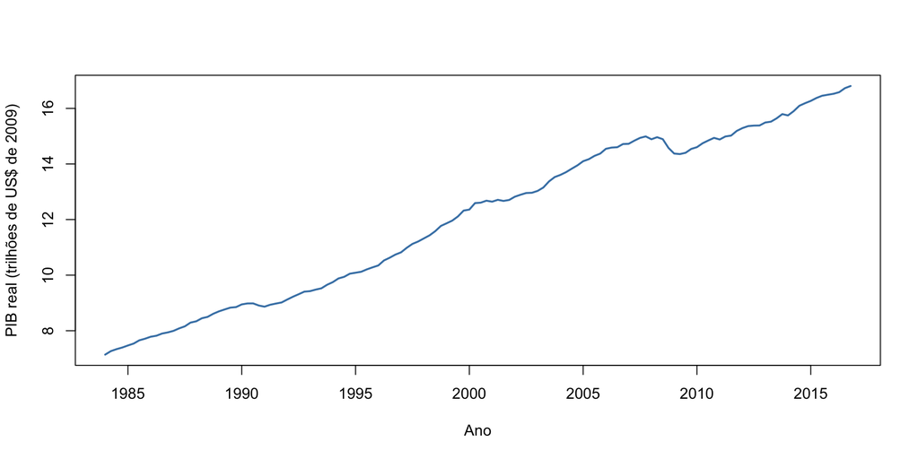

Fig. 1: PIB real dos EUA — 1984Q1 a 2016Q4, como exemplo motivador de série **candidata a I(1)**. Tendência ascendente persistente — comportamento típico de série **I(1)**. O nível **não reverte** a uma média constante ⇒ improvável ser estacionária.

## Autocorrelação: nível e diferenças

```r
# colocamos nível e diferença lado a lado
# para comparar a persistência antes e depois de diferenciar
par(mfrow = c(1, 2))
acf(gdp_ts[, "gdp"],       main = "PIB — nível")
acf(diff(gdp_ts[, "gdp"]), main = "PIB — Δ")
```

## Autocorrelação: nível e diferenças

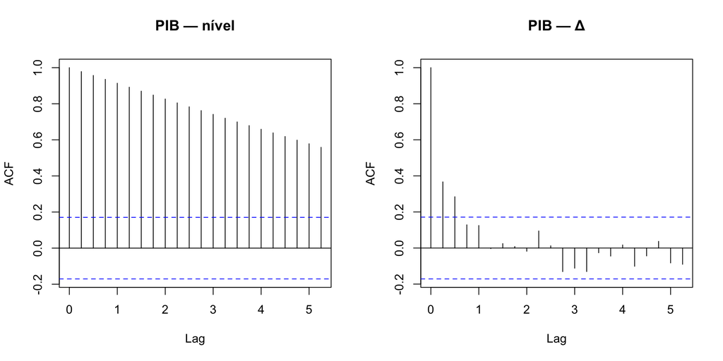

Fig. 2: **Nível**: FAC decai muito lentamente ⇒ forte evidência de **raiz unitária**. **Primeiras diferenças**: decaimento rápido ⇒ compatível com **I(0)**. Essa é a assinatura esperada de uma série **I(1)**.

## Exemplo cointegrado

**Contexto empírico**

- **`ffr`**, taxa overnight do mercado interbancário dos EUA, instrumento-chave da política monetária do Fed.
- **`br`** — *3-Year Treasury Constant Maturity Rate*, rendimento do título do Tesouro dos EUA com maturidade constante de 3 anos. Séries mensais em % a.a.
- Pela estrutura a termo das taxas de juros, `br` deve refletir as expectativas sobre `ffr` ao longo do horizonte de 3 anos mais um prêmio de prazo — daí a expectativa de que se movam juntas no longo prazo, ainda que cada uma isolada seja I(1).
- Ambas em % ao ano, frequência mensal.

## Hipótese de cointegração

**Hipótese econômica**

Portanto, suspeitamos que `br` e `ffr` sejam **I(1)**, mas que a combinação linear:

$$e_t = br_t - \beta_1 - \beta_2\, ffr_t$$

seja **I(0)** — isto é, que haja **cointegração**.

## `br` e `ffr`

```r
# o gráfico em conjunto ajuda a verificar
# se as taxas parecem compartilhar movimentos de longo prazo
ts.plot(usa_ts[, "br"], usa_ts[, "ffr"],
        col = c("darkgreen", "purple"),
        lty = c(1, 2), lwd = 2,
        ylab = "Taxa (% a.a.)")
legend("topright", legend = c("Bond rate (br)", "Fed funds (ffr)"),
       col = c("darkgreen", "purple"), lty = c(1, 2), bty = "n")
```

## `br` e `ffr`

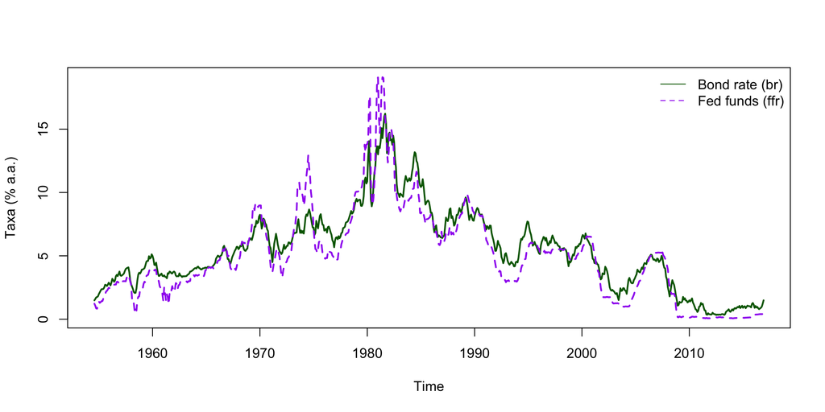

Fig. 3: Fed Funds Rate e Bond Rate (EUA, mensal)

## Engle–Granger: aplicação

**Relação de longo prazo**

- Estimamos por **MQO** a relação de equilíbrio entre `br` e `ffr`:
- Salvamos os **resíduos** $\hat{e}_t$:
- Se $\hat{e}_t$ for **I(0)**, há cointegração.
- Se for **I(1)**, a regressão é **espúria**.

## Código: passo 1

```r
# no passo 1, estimamos a relação em nível e guardamos os resíduos para o passo 2
lr_eq <- dynlm(br ~ ffr, data = usa_ts)

# resíduos que serão usados no teste de cointegração
ehat <- resid(lr_eq)

# exibe o resultado da regressão de longo prazo
summary(lr_eq)
```

## Resultados: passo 1

Relação de longo prazo: br = β₁ + β₂ ffr

| Termo | Estimativa | Erro-padrao | Estatistica | p-valor |
| --- | --- | --- | --- | --- |
| Intercepto | 1.328 | 0.059 | 22.399 | <0.001 |
| ffr | 0.832 | 0.010 | 85.717 | <0.001 |

## Engle–Granger: teste

**Teste nos resíduos**

- O gráfico sugere **persistência com deriva** nas séries, mas isso **não exige** incluir uma **tendência determinística linear** na relação cointegrante.
- Como a equação de longo prazo foi especificada com **intercepto**, mas **sem tendência determinística**, testamos os resíduos com ADF **sem constante e sem tendência**.

```r
# teste ADF
teste_adf <- ur.df(ehat,
  type = "none",
      lags = 12,
  selectlags = "BIC"
  )

# exibe o resultado
summary(teste_adf)
```

```
###############################################
# Augmented Dickey-Fuller Test Unit Root Test #
###############################################

Test regression none


Call:
lm(formula = z.diff ~ z.lag.1 - 1 + z.diff.lag)

Residuals:
     Min       1Q   Median       3Q      Max
-2.12785 -0.17463 -0.01621  0.15193  2.83051

Coefficients:
            Estimate Std. Error t value Pr(>|t|)
z.lag.1     -0.07021    0.01533  -4.579 5.49e-06 ***
z.diff.lag1  0.21948    0.03669   5.982 3.44e-09 ***
z.diff.lag2 -0.22116    0.03757  -5.887 6.00e-09 ***
z.diff.lag3  0.04484    0.03690   1.215    0.225
z.diff.lag4 -0.15895    0.03653  -4.351 1.55e-05 ***
---
Signif. codes:  0 '***' 0.001 '**' 0.01 '*' 0.05 '.' 0.1 ' ' 1

Residual standard error: 0.3655 on 731 degrees of freedom
Multiple R-squared:  0.1329,    Adjusted R-squared:  0.127
F-statistic: 22.41 on 5 and 731 DF,  p-value: < 2.2e-16


Value of test-statistic is: -4.579

Critical values for test statistics:
      1pct  5pct 10pct
tau1 -2.58 -1.95 -1.62
```

Estatística obtida:

$$tau_1 = -4.579$$

- O valor crítico padrão de $tau_1$ a 5% reportado por `ur.df()` é $-1.95$.
- Como $-4.579 < -1.95$, o ADF padrão rejeita a hipótese nula de raiz unitária nos resíduos.
- Como os resíduos são estimados no primeiro passo, a decisão formal deve usar os **valores críticos apropriados de Engle–Granger**, e não os valores críticos padrão do Dickey–Fuller.
- Em conjunto com o teste de Phillips–Ouliaris, isso fornece evidência consistente de que os resíduos são **I(0)**.
- Portanto, concluímos que `br` e `ffr` são **cointegradas**.

## Phillips–Ouliaris

**Lógica do teste**

Proposto por Phillips e Ouliaris (1990), é um **teste de cointegração baseado nos resíduos** da regressão estática de longo prazo — análogo ao Engle–Granger, mas com **correção não paramétrica** para autocorrelação e heterocedasticidade, dispensando a escolha de defasagens.

**Procedimento.** Dado $y_t, x_t \sim I(1)$, estima-se por MQO:

$$y_t = \beta_1 + \beta_2\, x_t + e_t,$$

recuperam-se os resíduos $\hat{e}_t$ e aplica-se uma **versão Phillips–Perron** do teste de raiz unitária sobre eles.

**Hipóteses.**

- $H_0$: $\hat{e}_t \sim I(1)$ ⇒ **não há cointegração**.
- $H_1$: $\hat{e}_t \sim I(0)$ ⇒ **há cointegração**.

**Nomenclatura.** Os autores propõem quatro estatísticas — $\hat{Z}_\alpha$, $\hat{Z}_t$, $\hat{P}_u$ e $\hat{P}_z$ —, tratadas genericamente como **testes $P_u$ e $P_z$ de cointegração** na literatura aplicada.

## Phillips–Ouliaris em R

**Implementação**

- Para manter consistência com os demais testes, usamos `ca.po()` do pacote `urca`.
- Neste exemplo, usamos `demean = "constant"` porque a relação de longo prazo foi especificada com **intercepto**, mas sem tendência determinística.
- Isso é coerente com a leitura do gráfico: pode haver **drift** nas séries I(1), mas não vemos evidência clara de uma **tendência linear determinística** que justificasse `demean = "trend"`.
- A hipótese nula continua sendo de **não cointegração**.

```r
# passamos as duas séries em nível
# como a relação de longo prazo inclui intercepto, usamos demean = "constant"
teste_po <- ca.po(
  cbind(usa_ts[, "br"], usa_ts[, "ffr"]),
  demean = "constant",
  type = "Pz",
  lag = "short"
)

summary(teste_po)
```

```
########################################
# Phillips and Ouliaris Unit Root Test #
########################################

Test of type Pz
detrending of series with constant only

Response usa_ts[, "br"] :

Call:
lm(formula = `usa_ts[, "br"]` ~ zr)

Residuals:
     Min       1Q   Median       3Q      Max
-2.58442 -0.17259  0.00206  0.16279  1.96947

Coefficients:
                  Estimate Std. Error t value Pr(>|t|)
(Intercept)       0.041776   0.028051   1.489    0.137
zrusa_ts[, "br"]  0.984841   0.013375  73.632   <2e-16 ***
zrusa_ts[, "ffr"] 0.008226   0.011680   0.704    0.481
---
Signif. codes:  0 '***' 0.001 '**' 0.01 '*' 0.05 '.' 0.1 ' ' 1

Residual standard error: 0.3502 on 745 degrees of freedom
Multiple R-squared:  0.9877,    Adjusted R-squared:  0.9876
F-statistic: 2.985e+04 on 2 and 745 DF,  p-value: < 2.2e-16


Response usa_ts[, "ffr"] :

Call:
lm(formula = `usa_ts[, "ffr"]` ~ zr)

Residuals:
    Min      1Q  Median      3Q     Max
-6.1843 -0.1030  0.0053  0.1140  3.2546

Coefficients:
                  Estimate Std. Error t value Pr(>|t|)
(Intercept)       -0.06126    0.04027  -1.521    0.129
zrusa_ts[, "br"]   0.08136    0.01920   4.238 2.54e-05 ***
zrusa_ts[, "ffr"]  0.92264    0.01677  55.030  < 2e-16 ***
---
Signif. codes:  0 '***' 0.001 '**' 0.01 '*' 0.05 '.' 0.1 ' ' 1

Residual standard error: 0.5027 on 745 degrees of freedom
Multiple R-squared:  0.9806,    Adjusted R-squared:  0.9806
F-statistic: 1.887e+04 on 2 and 745 DF,  p-value: < 2.2e-16



Value of test-statistic is: 109.7032

Critical values of Pz are:
                  10pct    5pct    1pct
critical values 47.5877 55.2202 71.9273
```

- Na saída, a estatística do teste é aproximadamente $Pz = 109{,}70$.
- O valor crítico de 5% é aproximadamente $55{,}22$. Como $109{,}70 > 55{,}22$, **rejeitamos** a hipótese nula de **não cointegração**.

Ou seja, o teste de Phillips-Ouliaris confirma o resultado do teste de Engle-Granger de que há evidência de que as séries `br` e `ffr` são cointegradas.

## Modelo ECM na prática

**Construção do modelo**

Uma relação entre variáveis **I(1) cointegradas** é uma **relação de longo prazo**, enquanto uma relação entre variáveis **I(0)** é uma **relação de curto prazo**.

O **modelo de correção de erros** (ECM) de curto prazo combina, em certo sentido, os efeitos de curto e de longo prazo.

Partindo de um **ARDL(1,1)**:

$$y_t = \delta + \theta_1\, y_{t-1} + \delta_0\, x_t + \delta_1\, x_{t-1} + v_t$$

e supondo que exista uma **relação de estado estacionário** (longo prazo) entre $y$ e $x$, pode-se derivar o **seguinte modelo de correção de erros**:

$$\Delta y_t = -\alpha\,(y_{t-1} - \beta_1 - \beta_2\, x_{t-1}) + \delta_0\, \Delta x_t + v_t$$

onde defasagens adicionais das diferenças de $x$ podem ser necessárias para **eliminar autocorrelação** nos resíduos.

## Especificação

**Equação estimada**

No caso do exemplo de títulos e fundos dos EUA, o modelo de correção de erros pode ser construído como:

$$\Delta br_t = -\alpha\left(br_{t-1} - \beta_1 - \beta_2\, ffr_{t-1}\right) + \delta_0 \, \Delta ffr_{t} + \delta_1 \, \Delta ffr_{t-1} + v_t$$

- $\beta_1, \beta_2$: parâmetros do **equilíbrio de longo prazo**.
- $\alpha > 0$: velocidade de **correção do desequilíbrio**.
- $\delta_0$: resposta **contemporânea de curto prazo**.
- $\delta_1$: resposta **defasada de curto prazo**.
- Como o ECM é **não linear nos parâmetros** ($\alpha$ multiplica $\beta_1$ e $\beta_2$), usamos a função `nls`, que estima o modelo por **mínimos quadrados não lineares**.

## Estimação do modelo ECM

```r
# construímos as diferenças e defasagens que entram diretamente na equação do ECM
usa_df_nls <- as.data.frame(usa_ts) |>
  select(br, ffr) |>
  mutate(d_br    = c(NA, diff(br)),           # Δbr_t
         d_ffr   = c(NA, diff(ffr)),          # Δffr_t
         L_br    = dplyr::lag(br),            # br_{t-1}
         L_ffr   = dplyr::lag(ffr),           # ffr_{t-1}
         L_d_ffr = dplyr::lag(d_ffr)) |>      # Δffr_{t-1}
  drop_na()

# estimação do ECM:
#   Δbr_t = -α (br_{t-1} - β1 - β2 ffr_{t-1})
#           + δ0 Δffr_t + δ1 Δffr_{t-1} + v_t
ecm_nls <- nls(
  d_br ~ -alpha * (L_br - beta1 - beta2 * L_ffr) +
         delta0 * d_ffr + delta1 * L_d_ffr,
  data  = usa_df_nls,
  start = list(alpha  = 0.1, beta1 = 1, beta2 = 1,
               delta0 = 0.5, delta1 = 0.2)
)

# exibe o resultado da estimação
summary(ecm_nls)
```

## Resultados: modelo ECM

ECM estimado por NLS

| Termo | Estimativa | Erro-padrao | Estatistica | p-valor |
| --- | --- | --- | --- | --- |
| α | 0.051 | 0.012 | 4.377 | < 0.001 |
| β₁ | 1.306 | 0.363 | 3.600 | < 0.001 |
| β₂ | 0.837 | 0.059 | 14.070 | < 0.001 |
| δ₀ | 0.394 | 0.024 | 16.553 | < 0.001 |
| δ₁ | -0.076 | 0.024 | -3.199 | 0.00144 |

## Leitura: modelo ECM

**Interpretação**

- Como `usa_ts` é **mensal**, a unidade temporal do ajuste é o **mês**. Com os coeficientes estimados:
- **$\hat{\alpha} = 0,0512$** : aproximadamente **5,1% do desvio** da relação de longo prazo é corrigido **a cada mês**. Meia-vida do desequilíbrio: $\ln(0{,}5)/\ln(1 - 0{,}0512) \approx 13$ **meses**.
- **$\hat{\beta}_1 = 1,3058$**: **intercepto** da relação de longo prazo entre $br$ e $ffr$ (em p.p.).
- **$\hat{\beta}_2 = 0,8369$**: **multiplicador de longo prazo** — um aumento permanente de 1 p.p. em $ffr$ eleva $br$ em cerca de **0,84 p.p.** no longo prazo. Como $\hat{\beta}_2 < 1$, o *bond rate* responde **menos que proporcionalmente** a variações permanentes na taxa *fed funds*.
- **$\hat{\delta}_0 = 0,3940$**: **efeito de impacto** — uma variação de 1 p.p. em $ffr_t$ eleva $br_t$ em cerca de **0,39 p.p.** no mesmo mês.
- **$\hat{\delta}_1 = -0,0757$**: **efeito defasado** — uma variação de 1 p.p. em $\Delta ffr_{t-1}$ reduz $\Delta br_t$ em cerca de **0,08 p.p.** (pequena reversão parcial do efeito de impacto).

**Leitura econométrica.** $\hat{\alpha} > 0$ e altamente significante é **consistente com ajuste convergente** ao equilíbrio. A legitimidade do ECM, porém, vem da evidência prévia de **cointegração** entre `br` e `ffr`.

## Ajuste ao equilíbrio

**Ajuste dinâmico**

Nos dois primeiros meses, o componente diretamente ligado às diferenças de `ffr` soma $\hat{\delta}_0 + \hat{\delta}_1 \approx 0{,}32$ p.p. Esse valor resume o **impacto líquido de curto prazo** capturado por $\Delta ffr_t$ e $\Delta ffr_{t-1}$, mas **não esgota** o efeito total de longo prazo.

A convergência para o multiplicador de longo prazo $\hat{\beta}_2 \approx 0{,}84$ ocorre **gradualmente** por meio do termo de correção de erros $-\hat{\alpha}\,(br_{t-1} - \hat{\beta}_1 - \hat{\beta}_2\, ffr_{t-1})$, à taxa de ~5,1% ao mês, com a trajetória convergindo para $\hat{\beta}_2$ ao longo de vários meses (meia-vida $\approx 13$ meses).

## Síntese: modelo ECM

**Papel da cointegração**

A **cointegração** entre `br` e `ffr` é o que **legitima** o ECM: ela é a ponte que permite combinar variáveis $I(1)$ — via o termo de correção de erros — e variáveis $I(0)$ — via as primeiras diferenças — na mesma equação, sem incorrer em regressão espúria.

Cada componente ganha um papel distinto: **as diferenças descrevem o ajuste de curto prazo**; **o termo de correção ancora a trajetória ao equilíbrio de longo prazo**.

Empiricamente, o ECM separou duas forças sobre o *bond rate*: um efeito contemporâneo de ~0,39 p.p. por variação unitária de `ffr` (curto prazo) e a convergência para um multiplicador de ~0,84 p.p. (longo prazo), via correção de ~5% do desvio ao mês.

## Exemplo sem cointegração

**Consequência prática**

- Se duas séries são I(1) e não cointegradas, a regressão em nível tende a ser espúria.
- Nesse caso, a saída prática é modelar em primeiras diferenças.
- Perdemos a relação de longo prazo, mas preservamos a dinâmica de curto prazo.

Ponte com aulas passadas: os testes de raiz unitária e o uso de tendência no Dickey-Fuller já foram discutidos anteriormente; aqui usamos esse resultado para decidir a forma do modelo.

## Exemplo: consumo e renda

**Pergunta empírica**

- Base: cons_inc.
- Amostra: 1985Q1 a 2016Q3.
- Pergunta: consumo e renda podem ser modelados em nível ou devem ser diferenciados?

## Código: níveis

```r
# carregamos a base que será usada para ilustrar o caso sem cointegração
data("cons_inc", package = "POE5Rdata")

# convertemos consumo e renda em objetos ts
# para usar diferenças e defasagens com calendário correto
consumo_ts <- ts(
  cons_inc$cons,
  start = c(1959, 3),
  end = c(2016, 3),
  frequency = 4
)

renda_ts <- ts(
  cons_inc$y,
  start = c(1959, 3),
  end = c(2016, 3),
  frequency = 4
)

# restringimos a amostra ao período discutido na aula
consumo_ts <- window(consumo_ts, start = c(1985, 1), end = c(2016, 3))
renda_ts   <- window(renda_ts,   start = c(1985, 1), end = c(2016, 3))

# passamos ao formato longo para empilhar as duas séries no mesmo código de gráfico
dados_nivel <- tibble(
  tempo = as.numeric(time(consumo_ts)),
  consumo = as.numeric(consumo_ts),
  renda = as.numeric(renda_ts)
) |>
  pivot_longer(
    cols = c(consumo, renda),
    names_to = "serie",
    values_to = "valor"
  )

# facet_wrap gera um painel para cada série, facilitando a inspeção visual em nível
ggplot(dados_nivel, aes(x = tempo, y = valor)) +
  geom_line(color = "#2C699A", linewidth = 0.8) +
  facet_wrap(~ serie, scales = "free_y", ncol = 1) +
  labs(
    title = "Consumo e renda disponível em nível",
    x = NULL,
    y = NULL
  ) +
  theme_minimal(base_size = 16)
```

## Níveis

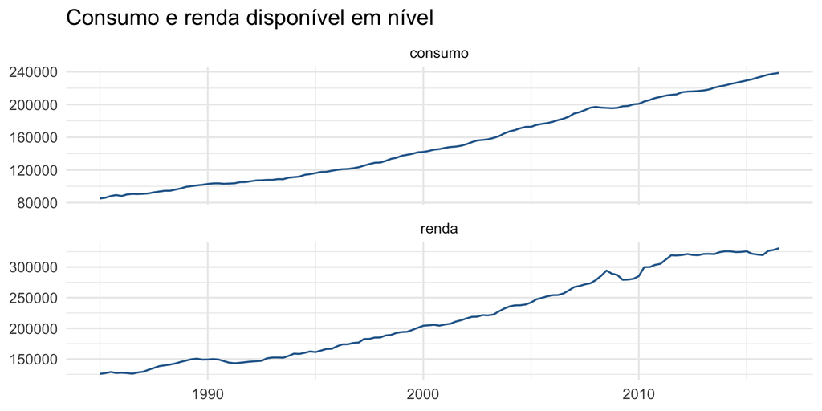

Consumo e renda disponível em nível, 1985Q1-2016Q3.

## Diagnóstico: níveis

**Sinal inicial**

- As duas séries exibem tendência.
- Portanto, seguimos com Dickey-Fuller incluindo tendência.
- Se forem I(1), ainda resta checar se há cointegração.

## Código: testes

```r
# primeiro testamos cada série em nível
# se ambas forem I(1), ainda precisaremos verificar cointegração
# selectlags = "BIC" escolhe automaticamente o número de defasagens do teste
teste_df_consumo <- ur.df(
  consumo_ts,
  type = "trend",
  selectlags = "BIC"
)

teste_df_renda <- ur.df(
  renda_ts,
  type = "trend",
  selectlags = "BIC"
)

# depois testamos se a combinação linear entre consumo e renda é estacionária
teste_po <- ca.po(
  cbind(consumo_ts, renda_ts),
  demean = "trend",
  type = "Pz",
  lag = "short"
)

# exibimos os três testes em sequência
# para comparar a decisão em nível e a decisão de cointegração
summary(teste_df_consumo)
summary(teste_df_renda)
summary(teste_po)
```

## Resultados: testes

```
###############################################
# Augmented Dickey-Fuller Test Unit Root Test #
###############################################

Test regression trend


Call:
lm(formula = z.diff ~ z.lag.1 + 1 + tt + z.diff.lag)

Residuals:
     Min       1Q   Median       3Q      Max
-2037.28  -529.44   -38.77   449.66  2303.86

Coefficients:
              Estimate Std. Error t value Pr(>|t|)
(Intercept) 2216.22747  841.19831   2.635  0.00952 **
z.lag.1       -0.02319    0.01166  -1.989  0.04900 *
tt            34.98634   15.08691   2.319  0.02207 *
z.diff.lag     0.24763    0.08677   2.854  0.00508 **
---
Signif. codes:  0 '***' 0.001 '**' 0.01 '*' 0.05 '.' 0.1 ' ' 1

Residual standard error: 796.5 on 121 degrees of freedom
Multiple R-squared:  0.1743,    Adjusted R-squared:  0.1538
F-statistic: 8.515 on 3 and 121 DF,  p-value: 3.546e-05


Value of test-statistic is: -1.9886 18.5089 5.2079

Critical values for test statistics:
      1pct  5pct 10pct
tau3 -3.99 -3.43 -3.13
phi2  6.22  4.75  4.07
phi3  8.43  6.49  5.47
```

```
###############################################
# Augmented Dickey-Fuller Test Unit Root Test #
###############################################

Test regression trend


Call:
lm(formula = z.diff ~ z.lag.1 + 1 + tt + z.diff.lag)

Residuals:
    Min      1Q  Median      3Q     Max
-8552.1 -1542.5    62.7  1257.2 12096.4

Coefficients:
              Estimate Std. Error t value Pr(>|t|)
(Intercept) 5359.72617 2033.51571   2.636  0.00950 **
z.lag.1       -0.04506    0.01979  -2.277  0.02452 *
tt            88.76733   36.92935   2.404  0.01775 *
z.diff.lag     0.25177    0.08646   2.912  0.00428 **
---
Signif. codes:  0 '***' 0.001 '**' 0.01 '*' 0.05 '.' 0.1 ' ' 1

Residual standard error: 2549 on 121 degrees of freedom
Multiple R-squared:  0.1076,    Adjusted R-squared:  0.0855
F-statistic: 4.864 on 3 and 121 DF,  p-value: 0.00314


Value of test-statistic is: -2.2773 9.0041 3.0275

Critical values for test statistics:
      1pct  5pct 10pct
tau3 -3.99 -3.43 -3.13
phi2  6.22  4.75  4.07
phi3  8.43  6.49  5.47
```

```
########################################
# Phillips and Ouliaris Unit Root Test #
########################################

Test of type Pz
detrending of series with constant and linear trend

Response consumo_ts :

Call:
lm(formula = consumo_ts ~ zr + trd)

Residuals:
    Min      1Q  Median      3Q     Max
-2189.7  -597.1     2.6   507.2  2538.9

Coefficients:
               Estimate Std. Error t value Pr(>|t|)
(Intercept)   2.266e+03  8.805e+02   2.573   0.0113 *
zrconsumo_ts  9.908e-01  2.515e-02  39.391   <2e-16 ***
zrrenda_ts   -8.365e-03  1.335e-02  -0.627   0.5321
trd           3.403e+01  1.563e+01   2.177   0.0314 *
---
Signif. codes:  0 '***' 0.001 '**' 0.01 '*' 0.05 '.' 0.1 ' ' 1

Residual standard error: 819.4 on 122 degrees of freedom
Multiple R-squared:  0.9997,    Adjusted R-squared:  0.9997
F-statistic: 1.382e+05 on 3 and 122 DF,  p-value: < 2.2e-16


Response renda_ts :

Call:
lm(formula = renda_ts ~ zr + trd)

Residuals:
    Min      1Q  Median      3Q     Max
-9097.9 -1421.7  -144.5  1371.5 12516.0

Coefficients:
              Estimate Std. Error t value Pr(>|t|)
(Intercept)  1.439e+03  2.778e+03   0.518    0.605
zrconsumo_ts 1.615e-01  7.936e-02   2.035    0.044 *
zrrenda_ts   8.833e-01  4.211e-02  20.976   <2e-16 ***
trd          1.548e+01  4.932e+01   0.314    0.754
---
Signif. codes:  0 '***' 0.001 '**' 0.01 '*' 0.05 '.' 0.1 ' ' 1

Residual standard error: 2585 on 122 degrees of freedom
Multiple R-squared:  0.9986,    Adjusted R-squared:  0.9986
F-statistic: 2.891e+04 on 3 and 122 DF,  p-value: < 2.2e-16



Value of test-statistic is: 31.9546

Critical values of Pz are:
                  10pct    5pct     1pct
critical values 71.9586 81.3812 102.0167
```

## Decisão: testes

**Decisão empírica**

- Para `consumo_ts`, a estatística $\tau_3 = -1,99$ fica acima do valor crítico de 5% ($-3,43$); assim, **não rejeitamos** a hipótese nula de raiz unitária.
- Para `renda_ts`, a estatística $\tau_3 = -2,28$ também fica acima de $-3,43$; novamente, **não rejeitamos** a hipótese nula de raiz unitária.
- Logo, as duas séries são tratadas como **não-estacionárias em nível**. Para esta aplicação, seguimos o ramo prático de séries **compatíveis com I(1)** e passamos a verificar se há cointegração.
- No teste de Phillips-Ouliaris, a estatística $Pz = 31,95$ fica abaixo até do valor crítico de 10% ($71,96$); portanto, **não rejeitamos** a hipótese nula de ausência de cointegração.
- Conclusão: como as séries são **não-estacionárias em nível** e o teste não aponta cointegração, a regressão em nível não é adequada; neste exemplo, o caminho correto é trabalhar com **primeiras diferenças**.

## Código: diferenças

```r
# sem cointegração, trabalhamos apenas com diferenças para evitar regressão espúria
# a defasagem de Δ consumo captura persistência de curto prazo na dinâmica da série
# a sintaxe d() e L() do dynlm deixa explícito
# que o modelo é estimado em diferenças e com defasagem
modelo_diff <- dynlm(
  d(consumo_ts) ~ d(renda_ts) + L(d(consumo_ts))
)
```

## Resultados: diferenças

Modelo em primeiras diferenças

| Termo | Estimativa | Erro-padrao | Estatistica | p-valor |
| --- | --- | --- | --- | --- |
| Intercepto | 772.471 | 129.013 | 5.988 | <0.001 |
| Δ renda | 0.056 | 0.028 | 2.027 | 0.0448 |
| L(Δ consumo) | 0.292 | 0.086 | 3.419 | <0.001 |

## Interpretação

**Pontos principais**

- Como não há cointegração, esta equação descreve apenas a **dinâmica de curto prazo** entre consumo e renda.
- O coeficiente de `d(renda_ts)` é $0,056$ e significante a 5%: um aumento de **1 unidade** na variação trimestral da renda está associado, em média, a um aumento de cerca de **0,056 unidade** na variação trimestral do consumo no mesmo período, na **mesma unidade de medida da base**.
- O coeficiente de `L(d(consumo_ts))` é $0,292$ e significante: a variação do consumo apresenta **persistência**, isto é, parte do movimento passado ainda afeta a variação corrente.
- O intercepto estimado é $772,47$: ele representa a variação média trimestral de `consumo_ts` quando `d(renda_ts) = 0` e `L(d(consumo_ts)) = 0`. Portanto, deve ser lido como uma **constante condicional** do modelo em diferenças, e não como uma relação de longo prazo.
- Como o modelo está em primeiras diferenças, os coeficientes **não** devem ser interpretados como uma relação de equilíbrio de longo prazo.

## Síntese final

**Pontos principais**

- Séries I(1) só devem entrar em nível em modelos de regressão quando houver cointegração.
- Como neste exemplo não encontramos cointegração, a especificação adequada é o **modelo final em primeiras diferenças**.
- A interpretação passa a ser de **curto prazo**, abrindo mão de uma relação de equilíbrio de longo prazo em nível.
- Cointegração e ECM formam o caminho apropriado quando há **equilíbrio de longo prazo**; sem cointegração, **diferenciar** é a escolha segura.
- **Sempre** precede o ECM um **teste de cointegração**; caso contrário, o modelo é inválido.

# Exercício

## Exercício

**Consolidação**

Considere as três situações abaixo. Em cada caso, responda concisamente:

1. A regressão em nível, após controlar a tendência quando necessário, faz sentido?
2. Há risco de regressão espúria?
3. O ECM é apropriado?
4. Qual decisão econométrica é mais adequada?

**Situação 1**

Duas séries crescem ao longo do tempo por causa de uma **tendência determinística comum**. Quando uma tendência temporal é incluída na regressão em nível, o coeficiente da variável explicativa perde significância.

**Situação 2**

Duas séries são não estacionárias em nível e a regressão entre elas apresenta alto $R^2$. Porém, os resíduos dessa regressão apresentam raiz unitária.

**Situação 3**

Duas séries são I(1). A regressão de longo prazo gera resíduos estacionários, e no ECM estimado o coeficiente do termo de correção de erros é negativo e estatisticamente significante.

**Ao final, associe cada situação à decisão mais adequada:**

1. incluir tendência na regressão em nível;
2. trabalhar em primeiras diferenças;
3. estimar relação de longo prazo e ECM.

## Fim da Disciplina

**Mensagem final**

- Agradeço pela participação, pelo diálogo e pela seriedade com que acompanharam esta disciplina.
- Esta primeira oferta foi também um processo de construção, e as contribuições de vocês ajudaram a dar forma ao curso.
- Espero que o conteúdo trabalhado seja, de alguma forma, útil em suas trajetórias acadêmica e profissional.

## Referências

BROOKS, C. **Introductory Econometrics For Finance**. 4th. ed. [s.l.] Cambridge University Press, 2019.

ENGLE, R. F.; GRANGER, C. W. J. [Co-integration and Error Correction: Representation, Estimation, and Testing](https://doi.org/10.2307/1913236). **Econometrica**, v. 55, n. 2, p. 251–276, 1987.

HILL, R. C.; GRIFFITHS, W. E.; JUDGE, G. G. **Econometria**. 3. ed. São Paulo: Saraiva, 2003.

MORETTIN, P. A. **Econometria Financeira: um curso em séries temporais e financeiras**. 2. ed. São Paulo: Edgard Blücher, 2011.

PHILLIPS, P. C. B.; OULIARIS, S. Asymptotic Properties of Residual Based Tests for Cointegration. **Econometrica**, v. 58, n. 1, p. 165–193, 1990.

WOOLDRIDGE, J. M. **Introdução à Econometria: Uma Abordagem Moderna**. Traducao Flávio E. F. Marques. 5. ed. São Paulo, Brasil: Cengage Learning, 2016.